# mainFascarza

```python
import math, os, random, sys, time, logging
import numpy as np
import tensorflow as tf
import data_utils
import seq2seq_model
from six.moves import xrange
```

### 1. Lectura de datos

**Descripción:** Método para la lectura de los datos de origen y de destino (idioma de origen: Inglés, idioma de destino: Francés)

**Argumentos:**

> <b>@source_path:</b> Ruta del archivo que contiene identificadores de tokens del idioma de origen.  
> <b>@target_path:</b> Ruta del archivo que contiene identificadores de tokens del idioma de destino;  
> debe haber una correspondencia entre el contenido del archivo de origen y destino : Por ejemplo  
> la n-ésima línea del contenido del archivo de destino debe contener la salida deseada de la n-ésima  
> línea del contenido del archivo de origen.  
> <b>@max_size:</b> Número máximo de líneas a leer, si toma el valor de 0 ó 'None'  
> se leerá todo el contenido de los archivos de datos.

**Retorna:**

> <b>@data_set:</b> Una lista de longitud igual a la de la lista de buckets definida en la segunda celda (_buckets);  
> data_set[n] contiene una lista de pares (origen, destino) leídas de los archivos de datos proporcionados  
> (con rutas @source_path y @target_path) que encajan en el n-ésimo bucket tal que len(origen) < _buckets[n][0]  
> y len(destino) < _buckets[n][1]; origen y destino son listas de identificadores de tokens.

```python
def read_data(source_path, target_path, max_size=None):
    data_set = [[] for _ in _buckets]
    with tf.gfile.GFile(source_path, mode="r") as source_file:
        with tf.gfile.GFile(target_path, mode="r") as target_file:
            source, target = source_file.readline(), target_file.readline()
            counter = 0
            while source and target and (not max_size or counter < max_size):
                counter += 1
                if counter % 100000 == 0:
                    print("    reading data line %d" % counter)
                    sys.stdout.flush()
                source_ids = [int(x) for x in source.split()]
                target_ids = [int(x) for x in target.split()]
                target_ids.append(data_utils.EOS_ID)
                for bucket_id, (source_size, target_size) in enumerate(_buckets):
                    if len(source_ids) < source_size and len(target_ids) < target_size:
                        data_set[bucket_id].append([source_ids, target_ids])
                        break
                source, target = source_file.readline(), target_file.readline()
    return data_set
```

### 2. Creación del model

**Descripción:** La clase seq2seq_model.Seq2SeqModel implementa una red neuronal recurrente multi-capa como codificador, y un decodificador basado en atención. Ésta clase implementa memoria de largo a corto plazo (LSTM en inglés), adicionalmente también permite el uso de unidades recurrentes cerradas (GRU en inglés). También permite el uso de softmax muestreado para el manejo de un vocabulario de gran volumen

**Argumentos:**

> <b>@from_vocab_size:</b> Tamaño del vocabulario en ingles.  
> <b>@to_vocab_size:</b> Tamaño del vocabulario en frances.  
> <b>@_buckets:</b> Duplas de buckets a usar en el preprocesamiento de la data (ingles, frances).  
> <b>@size:</b> Tamaño de las capas del modelo.  
> <b>@num_layers:</b> Numero de capas.  
> <b>@max_gradient_norm:</b> maxima norma de las gradientes (regularizacion).  
> <b>@batch_size:</b> Tamaño de los batch de entrenamiento.  
> <b>@learning_rate:</b> Ratio de aprendizaje.  
> <b>@learning_rate_decay_factor:</b> decaimiento del ratio de aprendizaje.  
> <b>@forward_only:</b> Si es verdadero. No se construye el paso hacia atrás en el modelo  
> <b>@dtype:</b> El tipo de datos que se usará para almacenar las variables internas, por ejemplo: tf.float32.

```python
learning_rate = 0.5
learning_rate_decay_factor = 0.99
max_gradient_norm = 5.0
batch_size = 256
size = 512
num_layers = 2
from_vocab_size = 40000
to_vocab_size = 40000
data_dir = 'results'
train_dir = 'train'
max_train_data_size = 6500000
steps_per_checkpoint = 100
use_fp16 = False
# Archivos de vocabulario:
# from_train_data = None
# to_train_data = None
# from_dev_data = None
# to_dev_data = None

# Duplas de buckets a usar en el preprocesamiento de la data (ingles, frances).
_buckets = [(5, 10), (10, 15), (20, 25), (40, 50)]
```

```python
def create_model(session, forward_only):
    """Create translation model and initialize or load parameters in session."""
    dtype = tf.float16 if use_fp16 else tf.float32
    model = seq2seq_model.Seq2SeqModel(
        from_vocab_size,
        to_vocab_size,
        _buckets,
        size,
        num_layers,
        max_gradient_norm,
        batch_size,
        learning_rate,
        learning_rate_decay_factor,
        forward_only=forward_only,
        dtype=dtype)
    ckpt = tf.train.get_checkpoint_state(train_dir)
    if ckpt and tf.train.checkpoint_exists(ckpt.model_checkpoint_path):
        print("Reading model parameters from %s" % ckpt.model_checkpoint_path)
        model.saver.restore(session, ckpt.model_checkpoint_path)
    else:
        print("Created model with fresh parameters.")
        session.run(tf.global_variables_initializer())
    return model
```

### 3. Entrenamiento

**Descripción:** Entrena el modelo de traduccion de ingles a frances usando el dataset WMT.  
Los comentarios se encuentran a lo largo del cuerpo del método train()

```python
def train():
    """Entrena el modelo de traduccion de ingles a frances usando el dataset WMT."""
    if from_train_data and to_train_data:
        # Carga la data del dataset WMT.
        from_train, to_train, from_dev, to_dev, _, _ = data_utils.prepare_data(
            data_dir,
            from_train_data, to_train_data,
            from_dev_data, to_dev_data,
            from_vocab_size, to_vocab_size)
    else:
        # Prepara la data del dataset WMT.
        print("Preparing WMT data in %s" % data_dir)
        from_train, to_train, from_dev, to_dev, _, _ = data_utils.prepare_wmt_data(
            data_dir, from_vocab_size, to_vocab_size)

    with tf.Session() as sess:
        # Crea el modelo.
        print("Creating %d layers of %d units." % (num_layers, size))
        model = create_model(sess, False)

        # Lee la data en buckets y computa sus tamaños.
        print ("Reading development and training data (limit: %d)."
                 % max_train_data_size)
        dev_set = read_data(from_dev, to_dev)
        train_set = read_data(from_train, to_train, max_train_data_size)
        train_bucket_sizes = [len(train_set[b]) for b in xrange(len(_buckets))]
        train_total_size = float(sum(train_bucket_sizes))

        # El bucket scale es una lista de numeros incrementales de 0 a 1 que se usa
        # para seleccionar un bucket especifico. El tamaño de [scale[i], scale[i+1]]
        # es proporcional al tamaño del bucket i.
        train_buckets_scale = [sum(train_bucket_sizes[:i + 1]) / train_total_size
                                 for i in xrange(len(train_bucket_sizes))]

        # Loop de entrenamiento.
        step_time, loss = 0.0, 0.0
        current_step = 0
        previous_losses = []
        while True:
            # Se escoge un bucket de acuerdo a la distribucion de la data. Se escoge
            # un numero random entre [0, 1] y se usa el correspondiente intervalo en
            # train_buckets_scale.
            random_number_01 = np.random.random_sample()
            bucket_id = min([i for i in xrange(len(train_buckets_scale))
                             if train_buckets_scale[i] > random_number_01])

            # Obtener un batch y hacer un step de entrenamiento.
            start_time = time.time()
            encoder_inputs, decoder_inputs, target_weights = model.get_batch(
                train_set, bucket_id)
            _, step_loss, _ = model.step(sess, encoder_inputs, decoder_inputs,
                                         target_weights, bucket_id, False)
            step_time += (time.time() - start_time) / steps_per_checkpoint
            loss += step_loss / steps_per_checkpoint
            current_step += 1

            # Cada cierto numero de pasos, se guarda un checkpoint, se muestran
            # las estadisticas y se ejecutan evaluaciones.
            if current_step % steps_per_checkpoint == 0:
                # Muestra las estadisticas del epoch previo.
                perplexity = math.exp(float(loss)) if loss < 300 else float("inf")
                print ("global step %d learning rate %.4f step-time %.2f perplexity "
                         "%.2f" % (model.global_step.eval(), model.learning_rate.eval(),
                                 step_time, perplexity))
                # Log de entrenamiento
                with open('log/train.txt', 'a') as f:
                    f.writelines('%.6f, %.6f\n' % (loss, perplexity))

                # Disminuye el learning rate si no hubo mejoras en el entrenamiento las
                # ultimas 3 epocas.
                if len(previous_losses) > 2 and loss > max(previous_losses[-3:]):
                    sess.run(model.learning_rate_decay_op)
                previous_losses.append(loss)
                # Se guarda un checkpoint.
                checkpoint_path = os.path.join(train_dir, "translate.ckpt")
                model.saver.save(sess, checkpoint_path, global_step=model.global_step)
                step_time, loss = 0.0, 0.0
                # Se ejecutan las evaluaciones en el development set y se imprime la
                # perplejidad.
                for bucket_id in xrange(len(_buckets)):
                    if len(dev_set[bucket_id]) == 0:
                        print("    eval: empty bucket %d" % (bucket_id))
                        continue
                    encoder_inputs, decoder_inputs, target_weights = model.get_batch(
                        dev_set, bucket_id)
                    _, eval_loss, _ = model.step(sess, encoder_inputs, decoder_inputs,
                                                 target_weights, bucket_id, True)
                    eval_ppx = math.exp(float(eval_loss)) if eval_loss < 300 else float(
                        "inf")
                    print("    eval: bucket %d perplexity %.2f" % (bucket_id, eval_ppx))

                    with open('log/test.txt', 'a') as f:
                        f.writelines('%d, %.6f, %.6f\n' % (bucket_id, eval_loss, eval_ppx))
```

### 4. Decodificación

**Descripción:** Carga y utiliza el modelo entrenado para traducir oraciones en inglés a francés.  
Los comentarios están en el cuerpo del método.

```python
def decode():
    with tf.Session() as sess:
        # Crea el modelo y carga los parametros.
        model = create_model(sess, True)
        model.batch_size = 1    # Se decodea una palabra a la vez.

        # Carga vocabularios en memoria.
        en_vocab_path = os.path.join(data_dir,
                                     "vocab%d.from" % from_vocab_size)
        fr_vocab_path = os.path.join(data_dir,
                                     "vocab%d.to" % to_vocab_size)
        en_vocab, _ = data_utils.initialize_vocabulary(en_vocab_path)
        _, rev_fr_vocab = data_utils.initialize_vocabulary(fr_vocab_path)

        # Lee texto del usuario.
        sentence = input('> ')
        while sentence:
            # Obtiene el token id de la oracion.
            token_ids = data_utils.sentence_to_token_ids(tf.compat.as_bytes(sentence), en_vocab)
            # Asigna la oracion a un bucket adecuado.
            bucket_id = len(_buckets) - 1
            for i, bucket in enumerate(_buckets):
                if bucket[0] >= len(token_ids):
                    bucket_id = i
                    break
            else:
                logging.warning("Sentence truncated: %s", sentence)

            # Crea un batch con la primera palabra.
            encoder_inputs, decoder_inputs, target_weights = model.get_batch(
                {bucket_id: [(token_ids, [])]}, bucket_id)
            # Obtiene los resultados del modelo (softmax).
            _, _, output_logits = model.step(sess, encoder_inputs, decoder_inputs,
                                             target_weights, bucket_id, True)
            # Se asigna como output el resultado con mayor valor (argmax).
            outputs = [int(np.argmax(logit, axis=1)) for logit in output_logits]
            # En caso de un token 'EOS' (end of sentence), se termina la traduccion.
            if data_utils.EOS_ID in outputs:
                outputs = outputs[:outputs.index(data_utils.EOS_ID)]
            # Muestra el resultado final.
            print(" ".join([tf.compat.as_str(rev_fr_vocab[output]) for output in outputs]))
            sys.stdout.flush()
            sentence = input('> ')
```

### Entrenamiento de la red

```python
train()
```

[output not shown]

[output cut: 964 more lines]

[output not shown]

### Gráficos para mostrar la evolución de la función de pérdida y perplejidad

```python
import pandas as pd
import matplotlib.pyplot as plt
%matplotlib inline
```

```
Training log:
Final loss=2.101810, final perplexity=8.180967
```

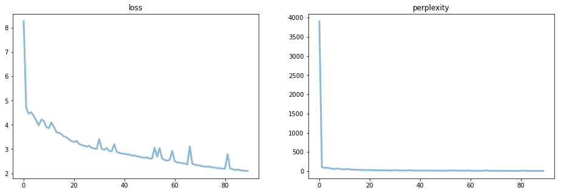

```
Evaluation log:
Bucket 0: loss=2.082066, ppx=8.021022 (eng_size:05, fr_size:10)
Bucket 1: loss=2.021780, ppx=7.551755 (eng_size:10, fr_size:15)
Bucket 2: loss=2.221751, ppx=9.223467 (eng_size:20, fr_size:25)
Bucket 3: loss=2.276136, ppx=9.738978 (eng_size:40, fr_size:50)
Avg loss=2.150433, Avg ppx=8.633806
```

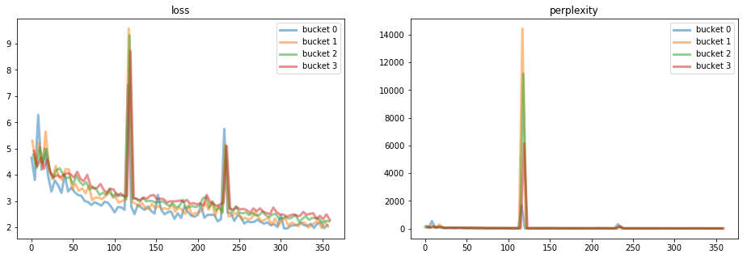

```python
train_log = pd.read_csv('log/train.txt', names=['loss', 'perplexity'])
fig, ax = plt.subplots(ncols=2, figsize=(16,5))
ax[0].set_title('loss')
ax[1].set_title('perplexity')
ax[0].plot(train_log['loss'], alpha=.5, linewidth=3)
ax[1].plot(train_log['perplexity'], alpha=.5, linewidth=3)
print('Training log:')
print('Final loss=%f, final perplexity=%f' %
      (train_log['loss'].values[-1],
       train_log['perplexity'].values[-1]))
plt.show()

test_log = pd.read_csv('log/test.txt', index_col=False, names=['bucket_id', 'eval_loss', 'eval_ppx'])
fig, ax = plt.subplots(ncols=2, figsize=(16,5))
ax[0].set_title('loss')
ax[1].set_title('perplexity')

for b in test_log.bucket_id.unique():
    ax[0].plot(test_log[test_log.bucket_id == b]['eval_loss'], label=f'bucket {b}', alpha=.5, linewidth=3)
    ax[1].plot(test_log[test_log.bucket_id == b]['eval_ppx'], label=f'bucket {b}', alpha=.5, linewidth=3)

for a in ax: a.legend()
print('Evaluation log:')

for i, bs in enumerate(_buckets):
    print(f'Bucket {i}: loss=%f, ppx=%f (eng_size:{bs[0]:02}, fr_size:{bs[1]})' %
          (test_log['eval_loss'].values[i-4], test_log['eval_ppx'].values[i-4]))

print('Avg loss=%f, Avg ppx=%f' %
      (np.mean(test_log['eval_loss'].values[-4:]),
       np.mean(test_log['eval_ppx'].values[-4:])))

# _buckets = [(5, 10), (10, 15), (20, 25), (40, 50)]
plt.show()
```

### Probando la red entrenada

```python
decode()
```

```
Reading model parameters from train/translate.ckpt-18900
> This is great.
Ce sont les résultats .
> My name is tensorflow.
Ce nom est _UNK .
> What is your name?
Ce nom est le nom ?
> I am trained to translate from english to french.
Les participants se _UNK à les _UNK à les _UNK .
> There are many words I don't know yet.
Il y existe que je ne _UNK pas .
```

[output not shown]